# check correlation of traits

Casey O’Hara

9/2/2020

## Load the data and clean up the values; then convert to ordered factors.

```
##    category            spp_gp             sheet             gen_time
##  Length:481         Length:481         Length:481         <1y   :118
##  Class :character   Class :character   Class :character   1-5y  :185
##  Mode  :character   Mode  :character   Mode  :character   5-10y : 28
##                                                           10-20y: 24
##                                                           >20y  :  5
##                                                           NA's  :121
##
##      opps        max_age
##  1     :249   3m-1y  :104
##  2-10  : 40   1-5y   : 96
##  11-25 : 24   5-10y  : 79
##  26-50 : 24   10-20y : 32
##  51-100: 11   20-100y: 49
##  100+  : 13   >100y  :  4
##  NA's  :120   NA's   :117
```

## check gen time against reproductive opportunities

For regressions, I am performing an ordinal logistic regression using `polr()` from the `MASS` package. See [this page](https://stats.idre.ucla.edu/r/dae/ordinal-logistic-regression/) for details

I wouldn’t expect strong correlation here between time to first reproduction and the number of lifetime opportunities.

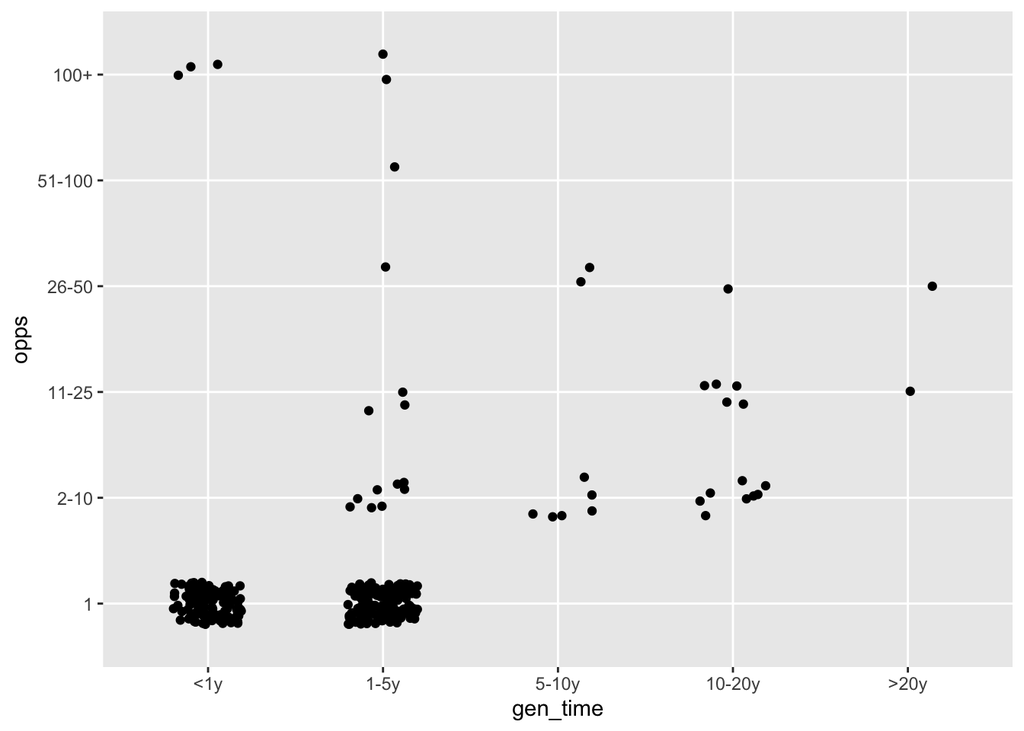

The plot doesn’t give us much help. Tons of fast-maturing species are one-and-done.

```
## Call:
## polr(formula = opps ~ gen_time, data = df1, Hess = TRUE)
##
## Coefficients:
##                Value Std. Error t value
## gen_time1-5y   1.425     0.6454   2.208
## gen_time5-10y  4.804     0.8379   5.734
## gen_time10-20y 4.903     0.7554   6.490
## gen_time>20y   5.864     1.2429   4.718
##
## Intercepts:
##              Value  Std. Error t value
## 1|2-10       3.6031 0.5852     6.1574
## 2-10|11-25   5.0759 0.6611     7.6785
## 11-25|26-50  5.8990 0.7066     8.3489
## 26-50|51-100 6.5736 0.7629     8.6167
## 51-100|100+  6.7565 0.7843     8.6144
##
## Residual Deviance: 256.122
## AIC: 274.122
```

Notation and concepts from [this page](https://stats.idre.ucla.edu/other/mult-pkg/faq/ologit/) and [this one](https://towardsdatascience.com/implementing-and-interpreting-ordinal-logistic-regression-1ee699274cf5):

Let $Y$ be an ordinal outcome with $J$ categories. Then $P(Y\leq J)$ is cumulative probability of $Y$ less than or equal to a specific category $j = 1, ..., J-1$. Note $P(Y \leq J) = 1$.

Odds of being less than or equal to a particular category can be defined as
$$\frac{P(Y \leq j)}{P(Y>j)}$$
for $j = 1, ..., J-1$ since $P(Y>J) = 0$ and can’t divide by zero. Log odds or *logit* is
$$log \left(\frac{P(Y \leq j)}{P(Y>j)}\right) = logit(P(Y\leq j))$$
Coefficients are interpreted as:
$$logit(P(Y \leq j)) = \beta_{j0} + \beta_{j1}x_1 + ... + \beta_{jp}x_p$$
which under the *parallel lines assumption* the intercepts are different for each category but slopes are constant across categories, so this simplifies to:
$$logit(P(Y \leq j)) = \beta_{j0} - [\beta_{1}x_1 + ... + \beta_{p}x_p]$$
and for a single predictor,
$$logit(P(Y \leq j)) = \beta_{j0} - \beta_{1}x_1$$
Here, $j = 1$ means 1 lifetime reproductive opportunity; $j = 2$ means 2-10 opportunities, etc. up to $j = 6$ for 100+ opportunities. Subscript 1 is coefficient for generation time, which here is just considered an unordered categorical variable with levels $1-5yrs, 5-10yrs, 10-20yrs, >20yrs$; $<1yr$ is absorbed by the intercept.

For $Y = 2$ (corresponding to 2-10
$$logit(P(Y \leq 2)) = 5.0759 - 1.425 = 3.6509$$
$$\Rightarrow P(Y \leq 2) = exp(3.6509)/(1 + exp(3.6509)) = 0.974$$
$$\Rightarrow P(Y = 2) = P(Y \leq 2) - P(Y \leq 1) = 0.974 - 0.898 = 0.076$$
so basically as your generation time increases, you have a small chance of bumping up in opportunities (since these seem to be dominated by one-shot spp)

Let’s apply that to max age against generation time which should be more decisive.

## check max age against gen time

I would expect a decent correlation between age to first reproduction and maximum age - at very least, the first is bounded on the top end by the second; and many long-lived creatures are known to take a long time to mature.

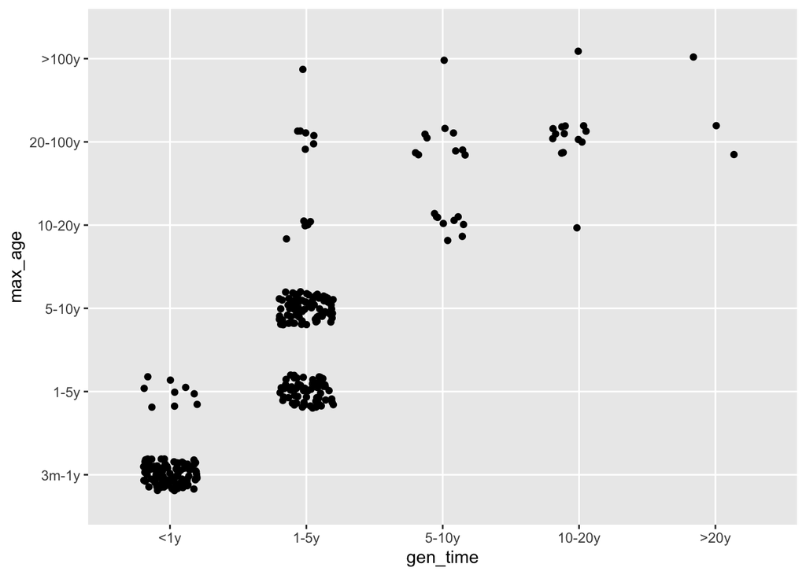

That looks like more of a regular pattern.

```
## Call:
## polr(formula = max_age ~ gen_time, data = df2, Hess = TRUE)
##
## Coefficients:
##                Value Std. Error t value
## gen_time1-5y   13.89      21.35  0.6507
## gen_time5-10y  18.10      21.36  0.8473
## gen_time10-20y 19.52      21.37  0.9134
## gen_time>20y   20.78      21.40  0.9711
##
## Intercepts:
##                Value   Std. Error t value
## 3m-1y|1-5y      2.4467  0.3474     7.0431
## 1-5y|5-10y     13.5065 21.3521     0.6326
## 5-10y|10-20y   16.3297 21.3540     0.7647
## 10-20y|20-100y 17.6597 21.3566     0.8269
## 20-100y|>100y  21.3481 21.3684     0.9990
##
## Residual Deviance: 431.3787
## AIC: 449.3787
```

These t values are all pretty small though. Not very convincing.

## check max age against reproductive opportunities

This would probably have a decent correlation, since living longer allows more seasons in which reproduction can occur.

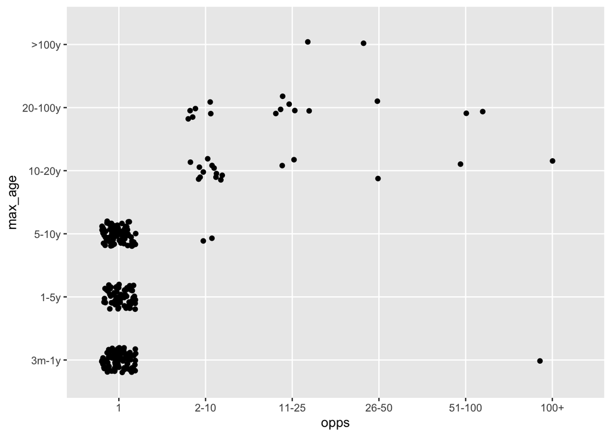

There seems to be a bit of a pattern here…

```
## Call:
## polr(formula = max_age ~ opps, data = df3, Hess = TRUE)
##
## Coefficients:
##             Value Std. Error t value
## opps2-10    7.911      1.261   6.275
## opps11-25  10.054      1.468   6.848
## opps26-50  10.455      1.887   5.542
## opps51-100  9.364      1.675   5.590
## opps100+    2.606      3.274   0.796
##
## Intercepts:
##                Value   Std. Error t value
## 3m-1y|1-5y     -0.3329  0.1285    -2.5905
## 1-5y|5-10y      0.7949  0.1366     5.8193
## 5-10y|10-20y    5.5871  1.0156     5.5013
## 10-20y|20-100y  8.8237  1.2785     6.9015
## 20-100y|>100y  12.0591  1.5141     7.9644
##
## Residual Deviance: 615.7499
## AIC: 635.7499
```

Check out those t-values! only the coefficient for 100+ is not significant.

Let’s figure out how to plot this on a heat map maybe.

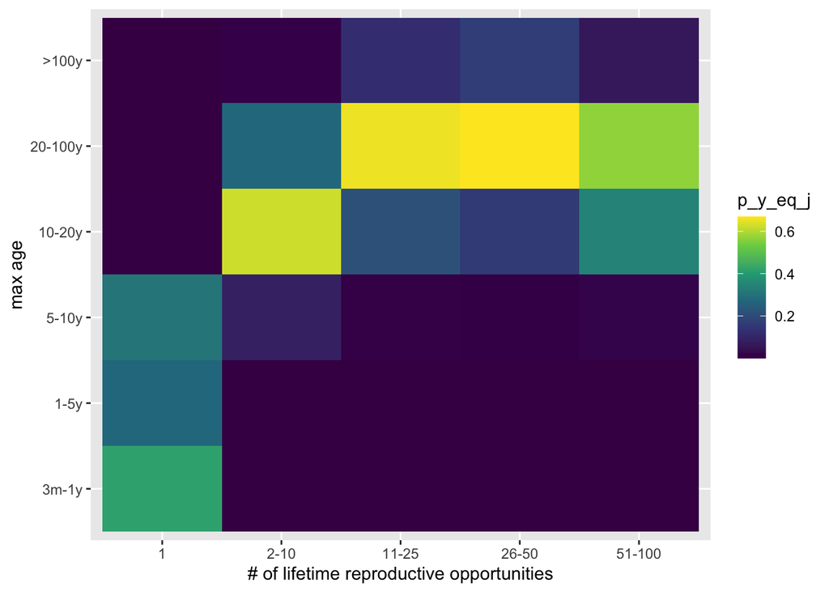

## check max age against reproductive opportunities and gen time

```
## Call:
## polr(formula = max_age ~ opps + gen_time, data = spp_reprod_fct,
##     Hess = TRUE)
##
## Coefficients:
##                 Value Std. Error    t value
## opps2-10       25.463  2.870e+01  8.871e-01
## opps11-25      34.134  3.115e+01  1.096e+00
## opps26-50      34.328  3.116e+01  1.102e+00
## opps51-100     43.933  6.315e+01  6.956e-01
## opps100+       -7.154  3.517e-04 -2.034e+04
## gen_time1-5y   13.864  1.178e+01  1.177e+00
## gen_time5-10y  15.689  1.190e+01  1.319e+00
## gen_time10-20y 32.023  2.307e+01  1.388e+00
## gen_time>20y   46.053  2.526e-02  1.823e+03
##
## Intercepts:
##                Value       Std. Error  t value
## 3m-1y|1-5y          2.4378      0.3476      7.0126
## 1-5y|5-10y         13.5988     11.7814      1.1543
## 5-10y|10-20y       38.8611     31.0110      1.2531
## 10-20y|20-100y     49.0130     33.2844      1.4726
## 20-100y|>100y      66.3051     40.3823      1.6419
##
## Residual Deviance: 264.6321
## AIC: 292.6321
## (209 observations deleted due to missingness)
```

Those t-values don’t look great.

## Are the dropped variables biased by taxon?

i.e. perhaps certain experts chose to code one variable to the exclusion of another.

| sheet | pct_na_max_age | pct_na_opps | pct_na_gen_time |
| --- | --- | --- | --- |
| cephalopods | 0.0039526 | 0.0000000 | 0.0000000 |
| corals | 0.0000000 | 0.0000000 | 0.6666667 |
| crustacea_arthropods | 1.0000000 | 0.0000000 | 0.7500000 |
| elasmobranchs | 0.4264706 | 0.4264706 | 0.4705882 |
| fish_Beth | 0.0000000 | 1.0000000 | 1.0000000 |
| marine_mammals | 0.3958333 | 0.6250000 | 0.4583333 |
| molluscs | 0.4000000 | 1.0000000 | 0.6000000 |
| plants_algae | 1.0000000 | 0.0000000 | 0.0000000 |
| polychaetes | 0.0000000 | 1.0000000 | 0.2500000 |
| reef_other_fish | 0.8846154 | 0.1538462 | 0.8076923 |
| reptiles | 1.0000000 | 0.0000000 | 0.7142857 |
| sea_snakes | 0.0000000 | 0.0000000 | 0.0000000 |
| seabirds | 0.5000000 | 1.0000000 | 0.2000000 |
| sponges | 1.0000000 | 0.0000000 | 1.0000000 |